# Darwin Core Archive QC Report

Tampa Bay Interagency Seagrass Monitoring Program

Published

June 30, 2026

## Overview

This report runs quality control checks on the Darwin Core Archive (DwC-A) produced by `R/convert_to_dwc.R` for the Tampa Bay Interagency Seagrass Monitoring Program. The archive consists of three files in `dwc/`:

| File | Content |
| --- | --- |
| `event.csv` | One row per transect visit (parent event) and meter mark observation (child event) |
| `occurrence.csv` | One row per species per meter mark, plus one absence record per bare point |
| `emof.csv` | Quantitative measurements (cover, blade length, shoot density, epiphyte density, sediment type) linked to each occurrence |

Checks use the [`obistools`](https://github.com/iobis/obistools) R package, which implements OBIS data quality requirements. Run `R/convert_to_dwc.R` first to generate the files in `dwc/` before rendering this report.

## Setup

```r
library(dplyr)
library(readr)
library(DT)
library(obistools)
library(here)

event      <- read_csv(here("dwc", "event.csv"),      show_col_types = FALSE)
occurrence <- read_csv(here("dwc", "occurrence.csv"), show_col_types = FALSE)
emof       <- read_csv(here("dwc", "emof.csv"),       show_col_types = FALSE)
```

Row counts for each output file.

| File | Rows |
| --- | --- |
| event.csv | 47346 |
| occurrence.csv | 54700 |
| emof.csv | 125775 |

## Taxa inventory

The table below lists all taxa resolved to accepted WoRMS names in the presence occurrence records. The AphiaID is extracted from the `scientificNameID` field, which is stored as a Life Science Identifier (LSID) of the form `urn:lsid:marinespecies.org:taxname:<id>`. The count column shows the number of occurrence records referencing each taxon across all transect visits.

```r
occurrence |>
  filter(occurrenceStatus == "present") |>
  mutate(
    AphiaID = as.integer(sub(".*:", "", scientificNameID)),
    WoRMS   = paste0(
      '<a href="https://www.marinespecies.org/aphia.php?p=taxdetails&id=',
      AphiaID, '" target="_blank">', AphiaID, "</a>"
    )
  ) |>
  count(scientificName, taxonRank, WoRMS, name = "occurrences") |>
  arrange(scientificName) |>
  datatable(
    escape   = FALSE,
    rownames = FALSE,
    options  = list(pageLength = 25, dom = "ftp"),
    colnames = c("Scientific name", "Rank", "AphiaID (WoRMS link)", "Occurrences")
  )
```

| Scientific name | Rank | AphiaID (WoRMS link) | Occurrences |
| --- | --- | --- | --- |
| Acanthophora | genus | 143900 | 782 |
| Caulerpa | genus | 143816 | 280 |
| Caulerpa mexicana | species | 144468 | 27 |
| Caulerpa prolifera | species | 144471 | 2106 |
| Caulerpa sertularioides | species | 144474 | 7 |
| Chaetomorpha | genus | 143995 | 67 |
| Chlorophyta | phylum (division) | 801 | 9 |
| Chondria | genus | 143906 | 8 |
| Dapis | genus | 1660763 | 161 |
| Dictyota | genus | 144086 | 1 |

[output cut: 20 more lines]

## Required fields

`check_fields()` verifies that all Darwin Core fields required by OBIS are present and non-empty. Required fields include `eventDate`, `decimalLatitude`, `decimalLongitude`, `scientificName`, `scientificNameID`, `occurrenceStatus`, and `basisOfRecord`. Recommended fields (`minimumDepthInMeters`, `maximumDepthInMeters`) are also checked at warning level.

Because the event core and occurrence extension split these fields across two files, the check is run on a flat table formed by joining occurrence records with their parent event rows.

```r
occ_flat <- occurrence |>
  inner_join(
    select(event, eventID, eventDate, decimalLatitude, decimalLongitude,
           minimumDepthInMeters, maximumDepthInMeters),
    by = "eventID"
  )

issues <- check_fields(occ_flat)

if (is.null(issues) || nrow(issues) == 0) {
  cat("No issues found.\n")
} else {
  datatable(issues, rownames = FALSE, options = list(pageLength = 15))
}
```

```
No issues found.
```

## Event ID integrity

`check_eventids()` verifies the internal consistency of the event hierarchy. It checks that `eventID` is present and unique across all rows, and that every `parentEventID` value references an `eventID` that exists in the same table. Orphaned child events — those whose `parentEventID` does not match any `eventID` — would prevent OBIS from assembling the transect-to-point hierarchy correctly.

In this archive, child events (meter mark visits, `eventType = "Point"`) link to parent events (transect visits, `eventType = "Transect"`) via `parentEventID`. Parent events have no `parentEventID` themselves.

```r
issues <- check_eventids(event)

if (is.null(issues) || nrow(issues) == 0) {
  cat("No issues found.\n")
} else {
  datatable(issues, rownames = FALSE, options = list(pageLength = 15))
}
```

```
No issues found.
```

## Occurrence ID integrity

`occurrenceID` must be unique across `occurrence.csv` — OBIS uses it as the stable identifier for each record, and duplicates indicate the conversion script fanned out rows it shouldn’t have (e.g. via a one-to-many join upstream). This check is not part of `obistools`, so it’s done here with plain `dplyr`.

```r
issues <- occurrence |>
  count(occurrenceID, name = "n") |>
  filter(n > 1)

if (nrow(issues) == 0) {
  cat("No issues found.\n")
} else {
  datatable(issues, rownames = FALSE, options = list(pageLength = 15))
}
```

```
No issues found.
```

## Extension linkage

These checks verify that the identifier fields in the extension files all reference valid rows in their respective core tables.

### Occurrence to event

`check_extension_eventids()` confirms that every `eventID` in `occurrence.csv` matches an `eventID` in `event.csv`. Any unmatched row would indicate an orphaned occurrence record that OBIS cannot link to a location or date.

```r
issues <- check_extension_eventids(event, occurrence)

if (is.null(issues) || nrow(issues) == 0) {
  cat("No issues found.\n")
} else {
  datatable(issues, rownames = FALSE, options = list(pageLength = 15))
}
```

```
No issues found.
```

### eMoF to event

`check_extension_eventids()` confirms that every `eventID` in `emof.csv` matches an `eventID` in `event.csv`. Any unmatched row would indicate a measurement record that cannot be linked to a location or date.

```r
issues <- check_extension_eventids(event, emof)

if (is.null(issues) || nrow(issues) == 0) {
  cat("No issues found.\n")
} else {
  datatable(issues, rownames = FALSE, options = list(pageLength = 15))
}
```

```
No issues found.
```

### eMoF to occurrence

`check_extension_eventids()` only verifies `eventID` linkage. An `anti_join()` is used separately to find any `occurrenceID` values in `emof.csv` that have no matching row in `occurrence.csv`. Any unmatched row would produce a measurement record with no associated taxon.

```r
issues <- anti_join(emof, occurrence, by = "occurrenceID")

if (nrow(issues) == 0) {
  cat("No issues found.\n")
} else {
  datatable(issues, rownames = FALSE, options = list(pageLength = 15))
}
```

```
No issues found.
```

## Event dates

`check_eventdate()` validates that all `eventDate` values conform to ISO 8601 format. OBIS requires dates as `YYYY-MM-DD`, `YYYY-MM-DDTHH:MM:SS`, or date ranges using `/` as a separator (e.g., `2022-06-01/2022-06-03`). Invalid or missing dates prevent records from appearing in OBIS temporal queries and are treated as errors during OBIS ingestion.

```r
issues <- check_eventdate(event)

if (is.null(issues) || nrow(issues) == 0) {
  cat("No issues found.\n")
} else {
  datatable(issues, rownames = FALSE, options = list(pageLength = 15))
}
```

```
No issues found.
```

## Depth QC

`check_depth()` flags records where reported depths are inconsistent with known bathymetry. It queries the OBIS xylookup service using the record coordinates and compares `minimumDepthInMeters` / `maximumDepthInMeters` against the modelled seabed depth at each point. A `depthmargin` of 20 m accounts for tidal variation, datum offsets, and measurement uncertainty. Records at coordinates landward of the shoreline are also flagged as likely coordinate errors.

Only child events carry depth values; parent events intentionally have `NA` for depth fields and are excluded before running the check.

```r
child_events <- event |>
  filter(!is.na(minimumDepthInMeters))

issues <- check_depth(child_events, report = TRUE, depthmargin = 20)

if (is.null(issues) || nrow(issues) == 0) {
  cat("No issues found.\n")
} else {
  datatable(issues, rownames = FALSE, options = list(pageLength = 15))
}
```

```
No issues found.
```

## Spatial distribution

`plot_map()` renders a static map of all event coordinates zoomed to the extent of the data. This provides a visual sanity check that points fall within Tampa Bay and that no coordinates are obviously misplaced (e.g., on land, in the wrong bay segment, or at 0, 0).

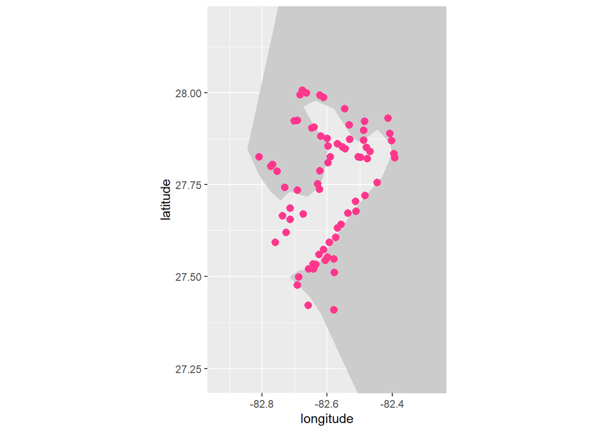

```r
plot_map(event, zoom = TRUE)
```

## Taxon name matching

`match_taxa()` cross-checks scientific names against WoRMS using the `wm_records_taxamatch` API endpoint, which applies fuzzy phonetic matching and returns multiple candidate matches ranked by similarity score. When more than one accepted WoRMS record matches a name, the function prompts interactively for the user to select the correct one.

This check is independent of the WoRMS lookup in `convert_to_dwc.R`, which uses `wm_records_names()`. It provides a second opinion that the resolved names are unambiguous in WoRMS. Because it requires interactive input it is not run during rendering — to use it, run the following in an interactive R session after loading the occurrence data:

```r
match_taxa(unique(occurrence$scientificName))
```

Names flagged as ambiguous by this function should be reviewed against the `aphia_overrides` vector in `convert_to_dwc.R` to confirm the correct AphiaID is pinned for each genus.